# Machine Learning 2021/2022 - Challenge

# Identification

```python
yourNameSurname='Andrea Bernini' # e.g., yourNameSurname='Mario Rossi'
yourMatricolaNumber='2021867' # e.g., yourMatricolaNumber='12345678'
yourStudentEMAIL='bernini.2021867@studenti.uniroma1.it' # e.g., yourStudentEMAIL='rossim.12345678@studenti.uniroma1.it'
```

## 1. Mandatory Rules:

- This year the results of the challenges will count 11,2/28 of your final grade (full info about grades here).
- Only one submission is allowed. We will not consider multiple submissions.
- Please remember your solution must be **"YOUR SOLUTION"**, hence you are requested to deliver your individual answers/arguments/opinions/critics.
- Mail your solution (with your **jupyter notebook** and the cleaned dataset) only to stefano.faralli@uniroma1.it **deadlines are announced on the ML google group and [here](https://twiki.di.uniroma1.it/twiki/view/ApprAuto) (NO EXCEPTIONS)** if you miss to deliver your solution you must wait the next (if any) available deadline.
- The subject of your email must be: "[ML-21-22-Challenge_solution] NAME - SURNAME - MATRICOLA".
- Double check the subject of your email and the attachments.
- In case you want to compress the attachment, **USE ONLY STANDARD ZIP compression** (NO RAR,7Z etc..).
- **Please sumbit The notebook (with SAVED OUTPUTS) and the cleaned dataset!**.
- Your solution might be considered as the "copy" of others solutions, in that specific case the resulting score for all involved students will be 0/8.
- Then read carefully all the part of the jupyter notebook and fill all fields.
- **solutions (and correspondig points) are evaluated mainly on your thoughts/comments/opinions**.
- If you have questions **Don't write "personal" emails** to Stefano Faralli, instead **use our google group**.
- A solution having a summary discussion with less than 500 words is evaluated with 0 points.
- Comments summary etc.. must be in **English**.

### Dataset and task Description:

[figure not shown]

- The challenge is about online news popularity;
- The provided dataset consists of one single csv file ("OnlineNewsPopularity.csv");
- The provided dataset is a modified **noisy** version of the original dataset described in [1];

[1] K. Fernandes, P. Vinagre and P. Cortez. A Proactive Intelligent Decision Support System for Predicting the Popularity of Online News. Proceedings of the 17th EPIA 2015 - Portuguese Conference on Artificial Intelligence, September, Coimbra, Portugal

This dataset summarizes a heterogeneous set of features about articles published by Mashable in a period of two years. The goal of the task is to predict the number of shares in social networks (popularity).

Number of Attributes: **61**

Target: **shares**

### Attribute Information:

| index | name | description |
| --- | --- | --- |
| 0 | url | URL of the article |
| 1 | timedelta | Days between the article publication and the dataset acquisition |
| 2 | n_tokens_title | Number of words in the title |
| 3 | n_tokens_content | Number of words in the content |
| 4 | n_unique_tokens | Rate of unique words in the content |
| 5 | n_non_stop_words | Rate of non-stop words in the content |
| 6 | n_non_stop_unique_tokens | Rate of unique non-stop words in content |
| 7 | num_hrefs | Number of links |
| 8 | num_self_hrefs | Number of links to other articles published by Mashable |
| 9 | num_imgs | Number of images |
| 10 | num_videos | Number of videos |
| 11 | average_token_length | Average length of the words in the content |
| 12 | num_keywords | Number of keywords in the metadata |
| 13 | data_channel_is_lifestyle | Is data channel 'Lifestyle'? |
| 14 | data_channel_is_entertainment | Is data channel 'Entertainment'? |
| 15 | data_channel_is_bus | Is data channel 'Business'? |
| 16 | data_channel_is_socmed | Is data channel 'Social Media'? |
| 17 | data_channel_is_tech | Is data channel 'Tech'? |
| 18 | data_channel_is_world | Is data channel 'World'? |
| 19 | kw_min_min | Worst keyword (min. shares) |
| 20 | kw_max_min | Worst keyword (max. shares) |
| 21 | kw_avg_min | Worst keyword (avg. shares) |
| 22 | kw_min_max | Best keyword (min. shares) |
| 23 | kw_max_max | Best keyword (max. shares) |
| 24 | kw_avg_max | Best keyword (avg. shares) |
| 25 | kw_min_avg | Avg. keyword (min. shares) |
| 26 | kw_max_avg | Avg. keyword (max. shares) |
| 27 | kw_avg_avg | Avg. keyword (avg. shares) |
| 28 | self_reference_min_shares | Min. shares of referenced articles in Mashable |
| 29 | self_reference_max_shares | Max. shares of referenced articles in Mashable |
| 30 | self_reference_avg_sharess | Avg. shares of referenced articles in Mashable |
| 31 | weekday_is_monday | Was the article published on a Monday? |
| 32 | weekday_is_tuesday | Was the article published on a Tuesday? |
| 33 | weekday_is_wednesday | Was the article published on a Wednesday? |
| 34 | weekday_is_thursday | Was the article published on a Thursday? |
| 35 | weekday_is_friday | Was the article published on a Friday? |
| 36 | weekday_is_saturday | Was the article published on a Saturday? |
| 37 | weekday_is_sunday | Was the article published on a Sunday? |
| 38 | is_weekend | Was the article published on the weekend? |
| 39 | LDA_00 | Closeness to LDA topic 0 |
| 40 | LDA_01 | Closeness to LDA topic 1 |
| 41 | LDA_02 | Closeness to LDA topic 2 |
| 42 | LDA_03 | Closeness to LDA topic 3 |
| 43 | LDA_04 | Closeness to LDA topic 4 |
| 44 | global_subjectivity | Text subjectivity |
| 45 | global_sentiment_polarity | Text sentiment polarity |
| 46 | global_rate_positive_words | Rate of positive words in the content |
| 47 | global_rate_negative_words | Rate of negative words in the content |
| 48 | rate_positive_words | Rate of positive words among non-neutral tokens |
| 49 | rate_negative_words | Rate of negative words among non-neutral tokens |
| 50 | avg_positive_polarity | Avg. polarity of positive words |
| 51 | min_positive_polarity | Min. polarity of positive words |
| 52 | max_positive_polarity | Max. polarity of positive words |
| 53 | avg_negative_polarity | Avg. polarity of negative words |
| 54 | min_negative_polarity | Min. polarity of negative words |
| 55 | max_negative_polarity | Max. polarity of negative words |
| 56 | title_subjectivity | Title subjectivity |
| 57 | title_sentiment_polarity | Title polarity |
| 58 | abs_title_subjectivity | Absolute subjectivity level |
| 59 | abs_title_sentiment_polarity | Absolute polarity level |
| 60 | shares | Number of shares (target) |

# 2. Pre-processing (up to 3 of 11.2 points)

## 2.1 Clean and Load the Dataset (up to 1 of 11.2 points)

Use the following two cells (a code cell and, a markdown cell) to:

- create a pandas DataFrame by loading a cleaned version of the "OnlineNewsPopularity.cvs" file.
- describe the identified noise and the methodology used to fix the problems.

```python
# Here we import all the necessary libreries and function that will be used
import pandas as pd
import numpy as np
# The next import is necessary to do the pre-processing phase
from sklearn import preprocessing
# We import the simple imputer algorithm
from sklearn.impute import SimpleImputer
from sklearn.impute import KNNImputer
from sklearn.preprocessing import MinMaxScaler
# We import the function SMOTENC to use the SMOTE technique also with categorical features
from imblearn.over_sampling import SMOTENC
import matplotlib.pyplot as plt
from matplotlib import pyplot
# We import the function train_test_split that splits the pandas dataframe in 2 parts
from sklearn.model_selection import train_test_split
# We import the functions necessary for the hyper parameter tuning
from sklearn.model_selection import GridSearchCV
from sklearn.model_selection import RandomizedSearchCV
# We import the functions that is used to instaciate a particular model
from sklearn import tree
from sklearn import svm
from sklearn.ensemble import RandomForestClassifier
from sklearn.neural_network import MLPClassifier
# We import the functions necessary to show the results of our models
from sklearn.metrics import confusion_matrix
from sklearn.metrics import classification_report
# We import the function to do the cross-validation
from sklearn.model_selection import cross_val_score
```

```python
online_news_popularity = pd.read_csv('OnlineNewsPopularity.csv', on_bad_lines='skip', low_memory=False)
# This code is used to load the cvs file, after 'OnlineNewsPopularity.csv'

online_news_popularity.head()
#Line 6 just print the "head" (i.e. the first 5 rows) of the pandas DataFrame defined in the above lines)
```

|  | url | timedelta | n_tokens_title | n_tokens_content | n_unique_tokens | n_non_stop_words | n_non_stop_unique_tokens | num_hrefs | num_self_hrefs | num_imgs | ... | min_positive_polarity | max_positive_polarity | avg_negative_polarity | min_negative_polarity | max_negative_polarity | title_subjectivity | title_sentiment_polarity | abs_title_subjectivity | abs_title_sentiment_polarity | shares |
| --- | --- | --- | --- | --- | --- | --- | --- | --- | --- | --- | --- | --- | --- | --- | --- | --- | --- | --- | --- | --- | --- |
| 0 | http://mashable.com/2013/01/07/amazon-instant-... | 731.0 | 12.0 | 219.0 | 0.663594 | 1.0 | 0.815385 | 4.0 | 2.0 | 1.0 | ... | 0.100000 | 0.7 | -0.350000 | -0.600 | -0.200000 | 0.500000 | -0.187500 | 0.000000 | 0.187500 | 593 |
| 1 | http://mashable.com/2013/01/07/ap-samsung-spon... | 731.0 | 9.0 | 255.0 | 0.604743 | 1.0 | 0.791946 | 3.0 | 1.0 | 1.0 | ... | 0.033333 | 0.7 | -0.118750 | -0.125 | -0.100000 | 0.000000 | 0.000000 | 0.500000 | 0.000000 | 711 |
| 2 | http://mashable.com/2013/01/07/apple-40-billio... | 731.0 | 9.0 | 211.0 | 0.575130 | 1.0 | 0.663866 | 3.0 | 1.0 | 1.0 | ... | 0.100000 | 1.0 | -0.466667 | -0.800 | -0.133333 | 0.000000 | 0.000000 | 0.500000 | 0.000000 | 1500 |
| 3 | http://mashable.com/2013/01/07/astronaut-notre... | 731.0 | 9.0 | 531.0 | 0.503788 | 1.0 | 0.665635 | 9.0 | 0.0 | 1.0 | ... | 0.136364 | 0.8 | -0.369697 | -0.600 | -0.166667 | 0.000000 | 0.000000 | 0.500000 | 0.000000 | 1200 |
| 4 | http://mashable.com/2013/01/07/att-u-verse-apps/ | 731.0 | 13.0 | 1072.0 | 0.415646 | 1.0 | 0.540890 | 19.0 | 19.0 | 20.0 | ... | 0.033333 | 1.0 | -0.220192 | -0.500 | -0.050000 | 0.454545 | 0.136364 | 0.045455 | 0.136364 | 505 |

5 rows × 61 columns

Viene usato l'attributo "on_bad_lines='skip'" perchè sono presenti delle righe con un numero di attributi maggiore di 61.

```python
# https://medium.com/@kyawsawhtoon/a-guide-to-knn-imputation-95e2dc496e
# One thing to note here is that the KNN Imputer does not recognize text data values.
# It will generate errors if we do not change these values to numerical values.
# A good way to modify the text data is to perform one-hot encoding or create “dummy variables”.
# The idea is to convert each category into a binary data column by assigning a 1 or 0.
# Other options would be to use LabelEncoder or OrdinalEncoder from Scikit-Learn’s preprocessing package.
cat_variables = online_news_popularity[['url']]
cat_dummies = pd.get_dummies(cat_variables, drop_first=True)
cat_dummies.head()
```

|  | url_0.999999995098 | url_8.0 | url_9990909 | url_http://mashable.com/2013/01/07/amazon-instant-video-browser/ | url_http://mashable.com/2013/01/07/ap-samsung-sponsored-tweets/ | url_http://mashable.com/2013/01/07/apple-40-billion-app-downloads/ | url_http://mashable.com/2013/01/07/astronaut-notre-dame-bcs/ | url_http://mashable.com/2013/01/07/att-u-verse-apps/ | url_http://mashable.com/2013/01/07/beewi-smart-toys/ | url_http://mashable.com/2013/01/07/bodymedia-armbandgets-update/ | ... | url_http://mashable.com/2014/12/27/music-grid-outfits/ | url_http://mashable.com/2014/12/27/nike-marc-newson/ | url_http://mashable.com/2014/12/27/north-korea-internet-outage-2/ | url_http://mashable.com/2014/12/27/nypd-rafael-ramos-funeral/ | url_http://mashable.com/2014/12/27/protests-continue-ramos-funeral/ | url_http://mashable.com/2014/12/27/samsung-app-autism/ | url_http://mashable.com/2014/12/27/seth-rogen-james-franco-will-live-tweet-the-interview/ | url_http://mashable.com/2014/12/27/son-pays-off-mortgage/ | url_http://mashable.com/2014/12/27/ukraine-blasts/ | url_http://mashable.com/2014/12/27/youtube-channels-2015/ |
| --- | --- | --- | --- | --- | --- | --- | --- | --- | --- | --- | --- | --- | --- | --- | --- | --- | --- | --- | --- | --- | --- |
| 0 | 0 | 0 | 0 | 1 | 0 | 0 | 0 | 0 | 0 | 0 | ... | 0 | 0 | 0 | 0 | 0 | 0 | 0 | 0 | 0 | 0 |
| 1 | 0 | 0 | 0 | 0 | 1 | 0 | 0 | 0 | 0 | 0 | ... | 0 | 0 | 0 | 0 | 0 | 0 | 0 | 0 | 0 | 0 |
| 2 | 0 | 0 | 0 | 0 | 0 | 1 | 0 | 0 | 0 | 0 | ... | 0 | 0 | 0 | 0 | 0 | 0 | 0 | 0 | 0 | 0 |
| 3 | 0 | 0 | 0 | 0 | 0 | 0 | 1 | 0 | 0 | 0 | ... | 0 | 0 | 0 | 0 | 0 | 0 | 0 | 0 | 0 | 0 |
| 4 | 0 | 0 | 0 | 0 | 0 | 0 | 0 | 1 | 0 | 0 | ... | 0 | 0 | 0 | 0 | 0 | 0 | 0 | 0 | 0 | 0 |

5 rows × 39646 columns

```python
# Next, we will drop the original “url” column from the data frame and add the dummy variables.
online_news_popularity = online_news_popularity.drop(['url'], axis=1)
online_news_popularity = pd.concat([online_news_popularity, cat_dummies], axis=1)
online_news_popularity.head()
```

|  | timedelta | n_tokens_title | n_tokens_content | n_unique_tokens | n_non_stop_words | n_non_stop_unique_tokens | num_hrefs | num_self_hrefs | num_imgs | num_videos | ... | url_http://mashable.com/2014/12/27/music-grid-outfits/ | url_http://mashable.com/2014/12/27/nike-marc-newson/ | url_http://mashable.com/2014/12/27/north-korea-internet-outage-2/ | url_http://mashable.com/2014/12/27/nypd-rafael-ramos-funeral/ | url_http://mashable.com/2014/12/27/protests-continue-ramos-funeral/ | url_http://mashable.com/2014/12/27/samsung-app-autism/ | url_http://mashable.com/2014/12/27/seth-rogen-james-franco-will-live-tweet-the-interview/ | url_http://mashable.com/2014/12/27/son-pays-off-mortgage/ | url_http://mashable.com/2014/12/27/ukraine-blasts/ | url_http://mashable.com/2014/12/27/youtube-channels-2015/ |
| --- | --- | --- | --- | --- | --- | --- | --- | --- | --- | --- | --- | --- | --- | --- | --- | --- | --- | --- | --- | --- | --- |
| 0 | 731.0 | 12.0 | 219.0 | 0.663594 | 1.0 | 0.815385 | 4.0 | 2.0 | 1.0 | 0.0 | ... | 0 | 0 | 0 | 0 | 0 | 0 | 0 | 0 | 0 | 0 |
| 1 | 731.0 | 9.0 | 255.0 | 0.604743 | 1.0 | 0.791946 | 3.0 | 1.0 | 1.0 | 0.0 | ... | 0 | 0 | 0 | 0 | 0 | 0 | 0 | 0 | 0 | 0 |
| 2 | 731.0 | 9.0 | 211.0 | 0.575130 | 1.0 | 0.663866 | 3.0 | 1.0 | 1.0 | 0.0 | ... | 0 | 0 | 0 | 0 | 0 | 0 | 0 | 0 | 0 | 0 |
| 3 | 731.0 | 9.0 | 531.0 | 0.503788 | 1.0 | 0.665635 | 9.0 | 0.0 | 1.0 | 0.0 | ... | 0 | 0 | 0 | 0 | 0 | 0 | 0 | 0 | 0 | 0 |
| 4 | 731.0 | 13.0 | 1072.0 | 0.415646 | 1.0 | 0.540890 | 19.0 | 19.0 | 20.0 | 0.0 | ... | 0 | 0 | 0 | 0 | 0 | 0 | 0 | 0 | 0 | 0 |

5 rows × 39706 columns

```python
# Another critical point here is that the KNN Imptuer is a distance-based imputation method and
# it requires us to normalize our data. Otherwise, the different scales of our data will lead the KNN Imputer
# to generate biased replacements for the missing values. For simplicity, we will use Scikit-Learn’s
# MinMaxScaler which will scale our variables to have values between 0 and 1.
scaler = MinMaxScaler()

online_news_popularity = pd.DataFrame(scaler.fit_transform(online_news_popularity[:61]), columns = online_news_popularity.columns)
online_news_popularity.head()
```

|  | timedelta | n_tokens_title | n_tokens_content | n_unique_tokens | n_non_stop_words | n_non_stop_unique_tokens | num_hrefs | num_self_hrefs | num_imgs | num_videos | ... | url_http://mashable.com/2014/12/27/music-grid-outfits/ | url_http://mashable.com/2014/12/27/nike-marc-newson/ | url_http://mashable.com/2014/12/27/north-korea-internet-outage-2/ | url_http://mashable.com/2014/12/27/nypd-rafael-ramos-funeral/ | url_http://mashable.com/2014/12/27/protests-continue-ramos-funeral/ | url_http://mashable.com/2014/12/27/samsung-app-autism/ | url_http://mashable.com/2014/12/27/seth-rogen-james-franco-will-live-tweet-the-interview/ | url_http://mashable.com/2014/12/27/son-pays-off-mortgage/ | url_http://mashable.com/2014/12/27/ukraine-blasts/ | url_http://mashable.com/2014/12/27/youtube-channels-2015/ |
| --- | --- | --- | --- | --- | --- | --- | --- | --- | --- | --- | --- | --- | --- | --- | --- | --- | --- | --- | --- | --- | --- |
| 0 | 0.0 | 0.750 | 0.105995 | 0.637571 | 0.663952 | 0.742012 | 0.148148 | 0.083333 | 0.02381 | 0.0 | ... | 0.0 | 0.0 | 0.0 | 0.0 | 0.0 | 0.0 | 0.0 | 0.0 | 0.0 | 0.0 |
| 1 | 0.0 | 0.375 | 0.137272 | 0.502670 | 0.715173 | 0.685337 | 0.111111 | 0.041667 | 0.02381 | 0.0 | ... | 0.0 | 0.0 | 0.0 | 0.0 | 0.0 | 0.0 | 0.0 | 0.0 | 0.0 | 0.0 |
| 2 | 0.0 | 0.375 | 0.099044 | 0.434788 | 0.626827 | 0.375633 | 0.111111 | 0.041667 | 0.02381 | 0.0 | ... | 0.0 | 0.0 | 0.0 | 0.0 | 0.0 | 0.0 | 0.0 | 0.0 | 0.0 | 0.0 |
| 3 | 0.0 | 0.375 | 0.377063 | 0.271256 | 0.903926 | 0.379911 | 0.333333 | 0.000000 | 0.02381 | 0.0 | ... | 0.0 | 0.0 | 0.0 | 0.0 | 0.0 | 0.0 | 0.0 | 0.0 | 0.0 | 0.0 |
| 4 | 0.0 | 0.875 | 0.847089 | 0.069212 | 0.990654 | 0.078273 | 0.703704 | 0.791667 | 0.47619 | 0.0 | ... | 0.0 | 0.0 | 0.0 | 0.0 | 0.0 | 0.0 | 0.0 | 0.0 | 0.0 | 0.0 |

5 rows × 39706 columns

```python
# Now that our dataset has dummy variables and normalized, we can move on to the KNN Imputation.
# So, the missing values will be replaced by the mean value of 5 nearest neighbors measured by Euclidean distance.
imputer = KNNImputer(n_neighbors=5)
online_news_popularity = pd.DataFrame(imputer.fit_transform(online_news_popularity),columns = online_news_popularity.columns)

# We will then use Pandas’ data frame attributes, ‘.isna()’ and ‘.isany()’, to detect missing values.
# These attributes will return Boolean values where ‘True’ indicates that there are missing values in
# the particular column.
online_news_popularity.isna().any()
# we can also use ‘.sum()’ to find out the number of missing values in the columns.
online_news_popularity.isna().sum()
```

```
 timedelta                                                                                   0
 n_tokens_title                                                                              0
 n_tokens_content                                                                            0
 n_unique_tokens                                                                             0
 n_non_stop_words                                                                            0
                                                                                            ..
url_http://mashable.com/2014/12/27/samsung-app-autism/                                       0
url_http://mashable.com/2014/12/27/seth-rogen-james-franco-will-live-tweet-the-interview/    0
url_http://mashable.com/2014/12/27/son-pays-off-mortgage/                                    0
url_http://mashable.com/2014/12/27/ukraine-blasts/                                           0
url_http://mashable.com/2014/12/27/youtube-channels-2015/                                    0
Length: 39706, dtype: int64
```

## 2.2 Dataset Analysis (up to 1 of 11.2 points)

In the following code cell (feel free to create new cells), remember to comment your code snippets:

1) Print the total number of samples;

2) Print a table with the first 15 samples;

3) Plot the histogram distribution of "shares";

4) A bar chart counting the attributes: data_channel_is_lifestyle, data_channel_is_entertainment, data_channel_is_bus, data_channel_is_socmed, data_channel_is_tech, data_channel_is_world;

### Code

1) Print the total number of samples;

```python
#This first code shows the "shape" of the CSV file (i.e. the shape of the samples)
online_news_popularity.shape

#This second code just show the lenght of the Pandas DataFrame
# len(online_news_popularity.index)
```

```
(61, 39706)
```

2) Print a table with the first 15 samples;

There are different ways to answer this question. In the following cell, we are going to show the easy way, but there are other methods that we can use, like:

1) online_news_popularity.loc[:15] that select the rows where we are interested to "by label";

2) online_news_popularity.iloc[:15,a:b] that select the rows where we are interested in "by position" and also allow us to select a range of features that we want to show. 'a' and 'b' represent, respectively, the start and the finish column (feature) that we want to show.

The difference with the respect to the first method is that in this method we only print the length of the pandas DataFrame and not also the number of features present in the DataSet.

```python
#This is the easy way, just take the samples from the first one to the 15th
online_news_popularity[:15]
```

|  | timedelta | n_tokens_title | n_tokens_content | n_unique_tokens | n_non_stop_words | n_non_stop_unique_tokens | num_hrefs | num_self_hrefs | num_imgs | num_videos | ... | url_http://mashable.com/2014/12/27/music-grid-outfits/ | url_http://mashable.com/2014/12/27/nike-marc-newson/ | url_http://mashable.com/2014/12/27/north-korea-internet-outage-2/ | url_http://mashable.com/2014/12/27/nypd-rafael-ramos-funeral/ | url_http://mashable.com/2014/12/27/protests-continue-ramos-funeral/ | url_http://mashable.com/2014/12/27/samsung-app-autism/ | url_http://mashable.com/2014/12/27/seth-rogen-james-franco-will-live-tweet-the-interview/ | url_http://mashable.com/2014/12/27/son-pays-off-mortgage/ | url_http://mashable.com/2014/12/27/ukraine-blasts/ | url_http://mashable.com/2014/12/27/youtube-channels-2015/ |
| --- | --- | --- | --- | --- | --- | --- | --- | --- | --- | --- | --- | --- | --- | --- | --- | --- | --- | --- | --- | --- | --- |
| 0 | 0.0 | 0.750 | 0.105995 | 0.637571 | 0.663952 | 0.742012 | 0.148148 | 0.083333 | 0.023810 | 0.000000 | ... | 0.0 | 0.0 | 0.0 | 0.0 | 0.0 | 0.0 | 0.0 | 0.0 | 0.0 | 0.0 |
| 1 | 0.0 | 0.375 | 0.137272 | 0.502670 | 0.715173 | 0.685337 | 0.111111 | 0.041667 | 0.023810 | 0.000000 | ... | 0.0 | 0.0 | 0.0 | 0.0 | 0.0 | 0.0 | 0.0 | 0.0 | 0.0 | 0.0 |
| 2 | 0.0 | 0.375 | 0.099044 | 0.434788 | 0.626827 | 0.375633 | 0.111111 | 0.041667 | 0.023810 | 0.000000 | ... | 0.0 | 0.0 | 0.0 | 0.0 | 0.0 | 0.0 | 0.0 | 0.0 | 0.0 | 0.0 |
| 3 | 0.0 | 0.375 | 0.377063 | 0.271256 | 0.903926 | 0.379911 | 0.333333 | 0.000000 | 0.023810 | 0.000000 | ... | 0.0 | 0.0 | 0.0 | 0.0 | 0.0 | 0.0 | 0.0 | 0.0 | 0.0 | 0.0 |
| 4 | 0.0 | 0.875 | 0.847089 | 0.069212 | 0.990654 | 0.078273 | 0.703704 | 0.791667 | 0.476190 | 0.000000 | ... | 0.0 | 0.0 | 0.0 | 0.0 | 0.0 | 0.0 | 0.0 | 0.0 | 0.0 | 0.0 |
| 5 | 0.0 | 0.500 | 0.237185 | 0.399852 | 0.830357 | 0.458651 | 0.074074 | 0.083333 | 0.000000 | 0.000000 | ... | 0.0 | 0.0 | 0.0 | 0.0 | 0.0 | 0.0 | 0.0 | 0.0 | 0.0 | 0.0 |
| 6 | 0.0 | 0.250 | 0.749783 | 0.074982 | 0.978853 | 0.099901 | 0.777778 | 0.833333 | 0.476190 | 0.000000 | ... | 0.0 | 0.0 | 0.0 | 0.0 | 0.0 | 0.0 | 0.0 | 0.0 | 0.0 | 0.0 |
| 7 | 0.0 | 0.750 | 0.774978 | 0.110308 | 0.982822 | 0.153760 | 0.740741 | 0.833333 | 0.476190 | 0.000000 | ... | 0.0 | 0.0 | 0.0 | 0.0 | 0.0 | 0.0 | 0.0 | 0.0 | 0.0 | 0.0 |
| 8 | 0.0 | 0.625 | 0.000000 | 0.652491 | 0.000000 | 0.793637 | 0.074074 | 0.000000 | 0.000000 | 0.000000 | ... | 0.0 | 0.0 | 0.0 | 0.0 | 0.0 | 0.0 | 0.0 | 0.0 | 0.0 | 0.0 |
| 9 | 0.0 | 0.500 | 0.116421 | 0.575152 | 0.687239 | 0.697803 | 0.148148 | 0.041667 | 0.023810 | 0.047619 | ... | 0.0 | 0.0 | 0.0 | 0.0 | 0.0 | 0.0 | 0.0 | 0.0 | 0.0 | 0.0 |
| 10 | 0.0 | 0.375 | 1.000000 | 0.239765 | 0.991855 | 0.539511 | 0.407407 | 0.000000 | 0.023810 | 0.000000 | ... | 0.0 | 0.0 | 0.0 | 0.0 | 0.0 | 0.0 | 0.0 | 0.0 | 0.0 | 0.0 |
| 11 | 0.0 | 0.500 | 0.078193 | 0.644613 | 0.611529 | 0.704811 | 0.259259 | 0.000000 | 0.023810 | 0.000000 | ... | 0.0 | 0.0 | 0.0 | 0.0 | 0.0 | 0.0 | 0.0 | 0.0 | 0.0 | 0.0 |
| 12 | 0.0 | 0.375 | 0.153779 | 0.512875 | 0.760234 | 0.481391 | 0.666667 | 0.083333 | 0.261905 | 0.000000 | ... | 0.0 | 0.0 | 0.0 | 0.0 | 0.0 | 0.0 | 0.0 | 0.0 | 0.0 | 0.0 |
| 13 | 0.0 | 0.375 | 0.163336 | 0.822307 | 0.780284 | 0.805232 | 0.148148 | 0.083333 | 0.000000 | 1.000000 | ... | 0.0 | 0.0 | 0.0 | 0.0 | 0.0 | 0.0 | 0.0 | 0.0 | 0.0 | 0.0 |
| 14 | 0.0 | 0.250 | 0.140747 | 0.406418 | 0.775480 | 0.328672 | 0.703704 | 0.125000 | 0.214286 | 0.000000 | ... | 0.0 | 0.0 | 0.0 | 0.0 | 0.0 | 0.0 | 0.0 | 0.0 | 0.0 | 0.0 |

15 rows × 39706 columns

3) Plot the histogram distribution of "shares";

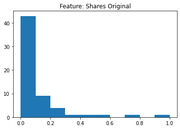

```python
#We first plot the feater "Features.Handheld?", that have a boolean type
# online_news_popularity[' shares'].value_counts().plot(kind='bar', title='Feature: Shares')


plt.hist(online_news_popularity[" shares"])  # arguments are passed to np.histogram
plt.title("Feature: Shares Original")
plt.show()

# quantile_transformer = preprocessing.QuantileTransformer(random_state=0,n_quantiles=61, output_distribution='normal')
# onp_qtrans = quantile_transformer.fit_transform(online_news_popularity)
#plt.hist(onp_qtrans[:,0])  # arguments are passed to np.histogram
#plt.title("Feature: Shares")
#plt.show()
```

4) A bar chart counting the attributes: data_channel_is_lifestyle, data_channel_is_entertainment, data_channel_is_bus, data_channel_is_socmed, data_channel_is_tech, data_channel_is_world;

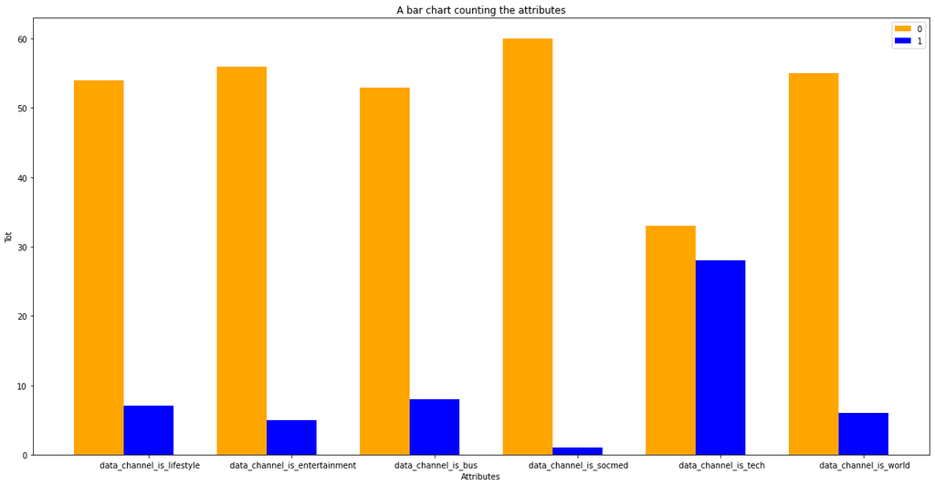

```python
attributes = [" data_channel_is_lifestyle", " data_channel_is_entertainment", " data_channel_is_bus", " data_channel_is_socmed", " data_channel_is_tech", " data_channel_is_world"]

total_zero = []
total_one = []
#print(online_news_popularity[" data_channel_is_world"].value_counts())

for attribute in attributes:
    total_zero.append(online_news_popularity[attribute].value_counts()[0]) # zero
    total_one.append(online_news_popularity[attribute].value_counts()[1])  # one

# Declaring the figure or the plot (y, x) or (width, height)
plt.figure(figsize=[20, 10])

# Using numpy to group different data with bars
X = np.arange(len(total_zero))
# Passing the parameters to the bar function, this is the main function which creates the bar plot
# Using X now to align the bars side by side

for attribute in attributes:
    plt.bar(X, total_zero, color = 'orange', width = 0.35)
    plt.bar(X + 0.35, total_one, color = 'blue', width = 0.35)

# Creating the legend of the bars in the plot
plt.legend(['0', '1'])

# Overiding the x axis with the country names
plt.xticks([i + 0.35 for i in range(len(attributes))], attributes)

# Giving the tilte for the plot
plt.title("A bar chart counting the attributes")

# Namimg the x and y axis
plt.xlabel('Attributes')
plt.ylabel('Tot')

# Saving the plot as a 'png'
#plt.savefig('4BarPlot.png')

# Displaying the bar plot
plt.show()
```